# HW3_Sol

Konstantinos Pasvantis

2022-11-05

## ΑΣΚΗΣΗ 1

#### Ερώτημα (α)

Διαβάζουμε τα δεδομένα από τον σύνδεσμο με την εντολή “dirty_iris<-read.csv(url(‘https://raw.githubusercontent.com/edwindj/datacleaning/master/data/dirty_iris.csv’))”. Δεν μπορουσε το R markdown file να διαβασει το dataset από τον σύνδεσμο, οπότε αποθήκευσα το csv file στον υπολογιστή και μετα το διάβασα από εκεί. Βλέπουμε μερικές από τις εγγραφές του dirty_iris που δημιουργήθηκε:

```r
library(dplyr)
dirty_iris<-read.csv('Dirty_iris.csv')
glimpse(dirty_iris)
```

```
## Rows: 150
## Columns: 5
## $ Sepal.Length <dbl> 6.4, 6.3, 6.2, 5.0, 5.7, 5.3, 6.4, 5.9, 5.8, 4.8, 5.0, 6.~
## $ Sepal.Width  <dbl> 3.2, 3.3, NA, 3.4, 2.6, NA, 2.7, 3.0, 2.7, 3.1, 3.5, 2.7,~
## $ Petal.Length <dbl> 4.5, 6.0, 5.4, 1.6, 3.5, NA, 5.3, 5.1, 4.1, 1.6, 1.6, 5.1~
## $ Petal.Width  <dbl> 1.5, 2.5, 2.3, 0.4, 1.0, 0.2, NA, 1.8, 1.0, 0.2, 0.6, 1.6~
## $ Species      <chr> "versicolor", "virginica", "virginica", "setosa", "versic~
```

Όπως μπορούμε να παρατηρήσουμε, η μεταβλητή species δεν είναι factor.

#### Ερώτημα (β)

Για να βροούμε τον αριθμό των complete cases στο dataset, χρησιμοποιούμε την εντολή complete.cases, σε συνδυασμό με την συνάρτηση εύρεσης αθροίσματος, και στην συνέχεια για το ζητούμενο ποσοστό αρκεί να διαιρέσω αυτόν τον αριθμό με τον συνολικό αριθμό παρατηρήσεων.

```r
sum(complete.cases(dirty_iris))
```

```
## [1] 96
```

```r
percentage<-sum(complete.cases(dirty_iris))/nrow(dirty_iris)
percentage
```

```
## [1] 0.64
```

#### Ερώτημα (γ)

Σύμφωνα με το βιβλίο στο οποίο είναι γραμμένες οι ασκήσεις, οι ειδικές τιμές είναι τα NA, NaN και Inf. Οπότε αρκεί να βρω αν υπάρχουν κάποιες άλλες εγγραφές είτε με NaN, είτε με Inf.

```r
library(tidyverse)
dirty_iris %>% filter_all(any_vars(. %in% c(NaN)))
```

```
## [1] Sepal.Length Sepal.Width  Petal.Length Petal.Width  Species
## <0 rows> (or 0-length row.names)
```

```r
dirty_iris %>% filter_all(any_vars(. %in% c(Inf)))
```

```
##   Sepal.Length Sepal.Width Petal.Length Petal.Width Species
## 1          5.1         3.8          1.9         Inf  setosa
```

Βλέπουμε ότι υπάρχει μία εγγραφή στην οποία η τιμή του πλάτους του πετάλου είναι ίση με Inf οπότε την αντικαθιστώ με NA.

```r
dirty_iris[dirty_iris==Inf]<-NA
dirty_iris %>% filter_all(any_vars(. %in% c(Inf)))
```

```
## [1] Sepal.Length Sepal.Width  Petal.Length Petal.Width  Species
## <0 rows> (or 0-length row.names)
```

## AΣΚΗΣΗ 2

#### Ερώτημα (α)

Σύμφωνα με τους κανόνες οι οποίοι αναγράφονται στην άσκηση, σχηματίζω ένα txt αρχείο με όνομα Iris_constraints στο οποίο γράφω: #numerical rules  
Petal.Witdh > 0  
Petal.Length > 0  
Sepal.Length > 0  
Sepal.Width > 0  
Petal.Length >= 2*Petal.Width  
Sepal.Length <= 30  
Sepal.Length > Petal.Length

#categorical rules  
Species %in% c(“setosa”, “versicolor”, “virginica”)

Οπότε πλεόν μπορώ να πάω να διαβάσω αυτό το αρχείο και θα έχω:

```r
library(editrules)
```

```r
E <- editfile("Iris_constraints.txt")
E
```

```
##
## Data model:
## dat1 : Species %in% c('setosa', 'versicolor', 'virginica')
##
## Edit set:
## num1 : 0 < Petal.Width
## num2 : 0 < Petal.Length
## num3 : 0 < Sepal.Length
## num4 : 0 < Sepal.Width
## num5 : 2*Petal.Width <= Petal.Length
## num6 : Sepal.Length <= 30
## num7 : Petal.Length < Sepal.Length
```

#### Ερώτημα (β)

Ακολουθώντας την θεωρία από το βιβλίο, σχηματίζω την μεταβλητή ve με τα violated edits του dataset, και στην συνέχεια σχηματίζω το γράφημα

```r
ve <- violatedEdits(E, dirty_iris)
summary(ve)
```

```
## Edit violations, 150 observations, 0 completely missing (0%):
##
##  editname freq  rel
##      num5    3   2%
##      num4    2 1.3%
##      num6    2 1.3%
##      num7    2 1.3%
##      num2    1 0.7%
##      num3    1 0.7%
##
## Edit violations per record:
##
##  errors freq   rel
##       0   90   60%
##       1   17 11.3%
##       2   13  8.7%
##       3   25 16.7%
##       4    4  2.7%
##       5    1  0.7%
```

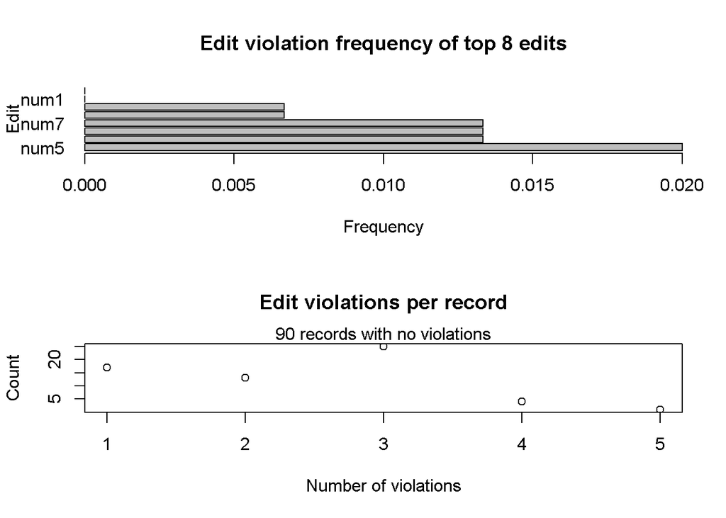

```r
plot(ve)
```

#### Ερώτημα (γ)

Αρκεί να δουύμε την τιμή του summary(ve), στην οποία αναγράφονται οι εγγραφές με κανένα παραβιασμό κάποιου κανόνα. Στην συγκεκριμένη περίπτωση βλέπουμε ότι έχουμε 90 τέτοιες εγγραφές.

#### Ερώτημα (δ)

Ο μόνος άνω φραγμένος περιορισμός που έχουμε όσον αφορά το μήκος του πετάλου, είναι ο num7, που μας λέει ότι το μήκος του πετάλου δεν πρέπει να υπερβαίνει το μήκος του σεπάλου. Για να βρόυμε ποιες εγγραφές είναι αυτές που παραβιάζουν αυτόν τον κανόνα χρησιμοποιώ την εντολή which():

```r
dirty_iris[which(dirty_iris$Petal.Length>=dirty_iris$Sepal.Length),]
```

```
##    Sepal.Length Sepal.Width Petal.Length Petal.Width    Species
## 35          6.6         2.9         23.0         1.3 versicolor
## 43          0.0          NA          1.3         0.4     setosa
```

#### Ερώτημα (ε)

Σχηματίζω το boxplot και στην συνέχεια βρίσκω ποιές τιμές είναι outliers για τις τιμές του σεπάλου.

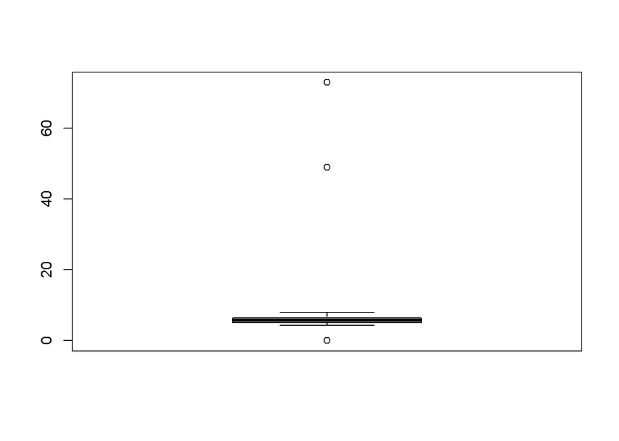

```
## [1] 73  0 49
```

```r
boxplot(dirty_iris$Sepal.Length)$out
```

Οπότε αρκεί να βρώ τις καταχωρήσεις στον πίνακα στις οποίες το μήκος του σεπάλου είναι ίσο με 0, 49 και 73.

```r
dirty_iris[which(dirty_iris$Sepal.Length == 0),]
```

```
##    Sepal.Length Sepal.Width Petal.Length Petal.Width Species
## 43            0          NA          1.3         0.4  setosa
```

```r
dirty_iris[which(dirty_iris$Sepal.Length == 73),]
```

```
##    Sepal.Length Sepal.Width Petal.Length Petal.Width   Species
## 28           73          29           63          NA virginica
```

```r
dirty_iris[which(dirty_iris$Sepal.Length == 49),]
```

```
##     Sepal.Length Sepal.Width Petal.Length Petal.Width Species
## 125           49          30           14           2  setosa
```

Το μόνο που μπορώ να σκεφτώ είναι ότι ξεχάστηκε να τοποιετηθεί το δεκαδικό ψηφίο, δηλαδή αντί για 73, το αποτέλεσμα να ήταν ίσο με 7.3, και το 0 έπρεπε να έιναι ένας φυσικός αριθμός όπως το 3, ή το 4 κ.ο.κ. Κάτι το οποίο θα έβγαζε και νόημα καθώς το εύρος των τιμών του μήκους των σεπάλων από οτι βλέπουμε από το γράφημα κυμαίνεται περίπου ανάμεσα στα 4 και στα 8 εκ.  
Τέλος, αντικαθιστώ τα outliers με ΝΑ.

```r
library(naniar)
dirty_iris1<-dirty_iris %>%
  replace_with_na(replace = list(Sepal.Length = c(73,49,0)))
```

## ΑΣΚΗΣΗ 3

#### Ερώτημα (α)

Η άσκηση λέει να αντικατασταθούν οι αρνητικές τιμές από την μεταβλητή Petal.Width, αλλά στην πραγματικότητα εννοεί τις αρνητικές τιμές από την Sepal.Width. Έτσι, σχηματίζουμε το CorrectionRules ως εξής:

```r
library(deducorrect)
u<-correctionRules(expression(
  if (is.na(Sepal.Width)) Sepal.Width<--1,
  if (Sepal.Width < 0) Sepal.Width<-NA
))
```

Εδώ πέρα αντικαθιστώ πρώτα τις NA τιμές με το -1 το οποίο είναι αρνητικός αριθμός, και στην συνέχεια το αλλάζει αυτόματα σε ΝΑ (Δεν μπορουσα να χρησιμοποιήσω την εντολή μόνο για να αλλάξω την μοναδική αρνητική τιμή, μου έβγαζε error).  
Στην συνέχεια χρησιμοποιώ την εντολή CorretWithRules και έχουμε το ζητούμενο αποτέλεσμα.

```r
correctWithRules(u,dirty_iris)
```

```
## $corrected
##     Sepal.Length Sepal.Width Petal.Length Petal.Width    Species
## 1            6.4         3.2        4.500         1.5 versicolor
## 2            6.3         3.3        6.000         2.5  virginica
## 3            6.2          NA        5.400         2.3  virginica
## 4            5.0         3.4        1.600         0.4     setosa
## 5            5.7         2.6        3.500         1.0 versicolor
## 6            5.3          NA           NA         0.2     setosa
## 7            6.4         2.7        5.300          NA  virginica
## 8            5.9         3.0        5.100         1.8  virginica
## 9            5.8         2.7        4.100         1.0 versicolor
## 10           4.8         3.1        1.600         0.2     setosa
## 11           5.0         3.5        1.600         0.6     setosa
## 12           6.0         2.7        5.100         1.6 versicolor
## 13           6.0         3.0        4.800          NA  virginica
```

[output cut: 175 more lines]

## ΑΣΚΗΣΗ 4

#### Ερώτημα (α)

Σύμφωνα με το βιβλίο για να γίνει το knn imputation το μόνο που χρειάζεται είναι μία εντολή. Δεν θέλουμε τις τελευταίες 5 νέες στήλες που σχηματίζονται.

```r
library(VIM)
dirty_iris2<- kNN(dirty_iris)%>% select(-c(6:10))
dirty_iris2
```

```
##     Sepal.Length Sepal.Width Petal.Length Petal.Width    Species
## 1            6.4         3.2        4.500         1.5 versicolor
## 2            6.3         3.3        6.000         2.5  virginica
## 3            6.2         3.2        5.400         2.3  virginica
## 4            5.0         3.4        1.600         0.4     setosa
## 5            5.7         2.6        3.500         1.0 versicolor
## 6            5.3         3.6        1.500         0.2     setosa
## 7            6.4         2.7        5.300         1.9  virginica
## 8            5.9         3.0        5.100         1.8  virginica
## 9            5.8         2.7        4.100         1.0 versicolor
## 10           4.8         3.1        1.600         0.2     setosa
## 11           5.0         3.5        1.600         0.6     setosa
## 12           6.0         2.7        5.100         1.6 versicolor
## 13           6.0         3.0        4.800         2.0  virginica
## 14           6.8         2.8        4.800         1.4 versicolor
```

[output cut: 136 more lines]

#### Ερώτημα (β)

Για να χρησιμοποιήσουμε την μέθοδο Sequential hotdeck imputation, παίρνουμε την έτοιμη συνάρτηση που δίνεται στο βιβλίο

```r
seqImpute <- function(x,last){
  n <- length(x)
  x <- c(x,last)
  i <- is.na(x)
  while(any(i)){
    x[i] <- x[which(i) + 1]
    i <- is.na(x)
  }
  x[1:n]
}
```

Στην συνέχεια κάνουμε arrange το dataset και παίρνουμε την στήλη με το πλάτος των πετάλων ώστε να το κάνουμε impute με την βοήθεια της συνάρτησης. Τέλος, αλλάζουμε τις τιμές του κανονικού dataset, με τις imputed, αφού το κάνουμε ξανά arrange σύμφωνα με τα είδη, και το νέο dataset το ονομάζουμε dirty_iris3.

```r
x1<-dirty_iris%>%arrange(Species)
dirty_iris3<-dirty_iris%>%arrange(Species)%>%mutate(Petal.Width=seqImpute(x1$Petal.Width,2))
dirty_iris3
```

```
##     Sepal.Length Sepal.Width Petal.Length Petal.Width    Species
## 1            5.0         3.4        1.600         0.4     setosa
## 2            5.3          NA           NA         0.2     setosa
## 3            4.8         3.1        1.600         0.2     setosa
## 4            5.0         3.5        1.600         0.6     setosa
## 5             NA         3.9        1.700         0.4     setosa
## 6            4.7         3.2        1.300         0.2     setosa
## 7             NA         4.0           NA         0.2     setosa
## 8            4.9         3.6           NA         0.1     setosa
## 9            4.6         3.2        1.400         0.2     setosa
## 10           4.9         3.1        1.500         0.1     setosa
## 11           4.4         3.2           NA         0.2     setosa
## 12           4.8         3.0        1.400         0.1     setosa
## 13           5.0         3.0        1.600         0.2     setosa
## 14           5.0          NA        1.200         0.2     setosa
```

[output cut: 136 more lines]

Παρατηρούμε ότι οι τιμές NA που αντικαταστήθηκαν είναι παρόμοιες με τις τιμές των μηκών των πετάλων για κάθε είδος, εκτός από την παρατήρηση η οποία ακολουθείται απο μία παρατήρηση virginica.

#### Ερώτημα (γ)

Με το ίδιο σκεπτικό, κάνουμε ακριβώς τα ίδια πράγματα, μόνο που τώρα κάνουμε arrange ως προς το είδος αλλά και το μήκος των σεπάλων.

```r
x2<-dirty_iris%>%arrange(Species,Sepal.Length)
dirty_iris3<-dirty_iris%>%arrange(Species,Sepal.Length)%>%mutate(Petal.Width=seqImpute(x2$Petal.Width,2))
dirty_iris3
```

```
##     Sepal.Length Sepal.Width Petal.Length Petal.Width    Species
## 1            0.0          NA        1.300         0.4     setosa
## 2            4.3         3.0        1.100         0.1     setosa
## 3            4.4         3.2           NA         0.2     setosa
## 4            4.4         2.9        1.400         0.2     setosa
## 5            4.4         3.0        1.300         0.3     setosa
## 6            4.5         2.3        1.300         0.3     setosa
## 7            4.6         3.2        1.400         0.2     setosa
## 8            4.6         3.4        1.400         0.3     setosa
## 9            4.6         3.1        1.500         0.2     setosa
## 10           4.6         3.6           NA         0.2     setosa
## 11           4.7         3.2        1.300         0.2     setosa
## 12           4.7         3.2        1.600         0.2     setosa
## 13           4.8         3.1        1.600         0.2     setosa
## 14           4.8         3.0        1.400         0.1     setosa
```

[output cut: 136 more lines]